# The Analytics Edge

# Week 1

## Introduction

We can store categorical responses as factors:

```r
x <- c("yes","no","yes","yes","no","maybe","maybe")
class(x)
```

```
## [1] "character"
```

```r
y <- factor(x)
summary(y)
```

```
## maybe    no   yes
##     2     2     3
```

```r
table(x)
```

```
## x
## maybe    no   yes
##     2     2     3
```

We can also have numerical variables:

```r
inc <- c(1000,3000,500,200,14,25,345)
```

We can apply a function to people based on their responses:

```r
tapply(inc,x,mean)
```

```
##     maybe        no       yes
##  185.0000 1507.0000  566.6667
```

Moving on to matrices

```r
m <- matrix(3:8,nrow=3,ncol=2)
m #print m
```

```
##      [,1] [,2]
## [1,]    3    6
## [2,]    4    7
## [3,]    5    8
```

```r
# Get the 1st row, 2nd column element
m[1,2]
```

```
## [1] 6
```

```r
# get the dimensions of the matrix
dim(m)
```

```
## [1] 3 2
```

```r
# get the fourth object (go down the 1st column, then 2nd, etc.)
m[4]
```

```
## [1] 6
```

```r
# get the second column
m[,2]
```

```
## [1] 6 7 8
```

```r
# We can also use arrays in R:
s <- array(3:8,3:2)
z<-1:50
# reshape
dim(z) <- c(5,2,5)
z[5,2,1:5]
```

```
## [1] 10 20 30 40 50
```

```r
# diagonal matrix of size 10, identity of size 10
diag(10)
```

```
##       [,1] [,2] [,3] [,4] [,5] [,6] [,7] [,8] [,9] [,10]
##  [1,]    1    0    0    0    0    0    0    0    0     0
##  [2,]    0    1    0    0    0    0    0    0    0     0
##  [3,]    0    0    1    0    0    0    0    0    0     0
##  [4,]    0    0    0    1    0    0    0    0    0     0
##  [5,]    0    0    0    0    1    0    0    0    0     0
##  [6,]    0    0    0    0    0    1    0    0    0     0
##  [7,]    0    0    0    0    0    0    1    0    0     0
##  [8,]    0    0    0    0    0    0    0    1    0     0
##  [9,]    0    0    0    0    0    0    0    0    1     0
## [10,]    0    0    0    0    0    0    0    0    0     1
```

```r
# combine columns
cbind(1:3,4:6)
```

```
##      [,1] [,2]
## [1,]    1    4
## [2,]    2    5
## [3,]    3    6
```

```r
# combine rows
rbind(1:3,4:6)
```

```
##      [,1] [,2] [,3]
## [1,]    1    2    3
## [2,]    4    5    6
```

Moving on to matrix multiplication:

```r
z <- matrix(c(5,7,9,6,3,4),nrow=3,ncol=2)
y <- matrix(c(1,3,0,9,5,-1),nrow=3,ncol=2)
# We can do term-by-term multiplication
z*y
```

```
##      [,1] [,2]
## [1,]    5   54
## [2,]   21   15
## [3,]    0   -4
```

```r
# get transpose
t(y)
```

```
##      [,1] [,2] [,3]
## [1,]    1    3    0
## [2,]    9    5   -1
```

```r
# matrix multiply
z%*%t(y)
```

```
##      [,1] [,2] [,3]
## [1,]   59   45   -6
## [2,]   34   36   -3
## [3,]   45   47   -4
```

## Linear Algebra

Solving equations:

```r
a <- array(c(2,1,-1,2),c(2,2))
b <- c(4,4)
solve(a,b)
```

```
## [1] 2.4 0.8
```

The `solve(a,b)` command solves the system of linear equations:
$$\mathbf{A}\vec{x}=b$$
It returns the vector $\vec{x}$.

```r
t <- eigen(a) # get eigendecomposition
t$values      # eigenvalues
```

```
## [1] 2+1i 2-1i
```

```r
t$vectors     # eigenvectors
```

```
##                      [,1]                 [,2]
## [1,] 0.7071068+0.0000000i 0.7071068+0.0000000i
## [2,] 0.0000000-0.7071068i 0.0000000+0.7071068i
```

## Lists and Dataframes

We can initialise lists and combine them:

```r
# initialising some lists
karthik<-list(age=37,sex="M",child.ages=c(1,1))
sam<-list(age=24,sex="F",child.ages=NA)
c(karthik,sam)
```

```
## $age
## [1] 37
##
## $sex
## [1] "M"
##
## $child.ages
## [1] 1 1
##
## $age
## [1] 24
##
## $sex
## [1] "F"
##
## $child.ages
## [1] NA
```

As well as dataframes:

```r
d <- data.frame(names=c("karthik","sam","jim"),
                ages=c(36,34,40),
                sex=c("M","F","M"),
                children=c(2,0,1))
d[,1] # get first column
```

```
## [1] karthik sam     jim
## Levels: jim karthik sam
```

R has a few public datasets part of the standard library. To get the list of datasets:

```r
data(package="datasets")$results[,3]
```

```
##   [1] "AirPassengers"          "BJsales"
##   [3] "BJsales.lead (BJsales)" "BOD"
##   [5] "CO2"                    "ChickWeight"
##   [7] "DNase"                  "EuStockMarkets"
##   [9] "Formaldehyde"           "HairEyeColor"
##  [11] "Harman23.cor"           "Harman74.cor"
##  [13] "Indometh"               "InsectSprays"
##  [15] "JohnsonJohnson"         "LakeHuron"
##  [17] "LifeCycleSavings"       "Loblolly"
##  [19] "Nile"                   "Orange"
##  [21] "OrchardSprays"          "PlantGrowth"
##  [23] "Puromycin"              "Seatbelts"
##  [25] "Theoph"                 "Titanic"
##  [27] "ToothGrowth"            "UCBAdmissions"
##  [29] "UKDriverDeaths"         "UKgas"
```

[output cut: 37 more lines]

```r
# This prints a list of datasets available into the final R Markdown Document
# Using the command `data()` will open a new window with the dataset names
```

## Old Faithful

To load the dataset relating to the Old Faithful geyser:

```r
data(faithful) #load the faithful dataset
str(faithful) #get the structure of R
```

```
## 'data.frame':    272 obs. of  2 variables:
##  $ eruptions: num  3.6 1.8 3.33 2.28 4.53 ...
##  $ waiting  : num  79 54 74 62 85 55 88 85 51 85 ...
```

```r
# note that str does not mean string in R
```

We will do statistical analysis on the Old Faithful dataset:

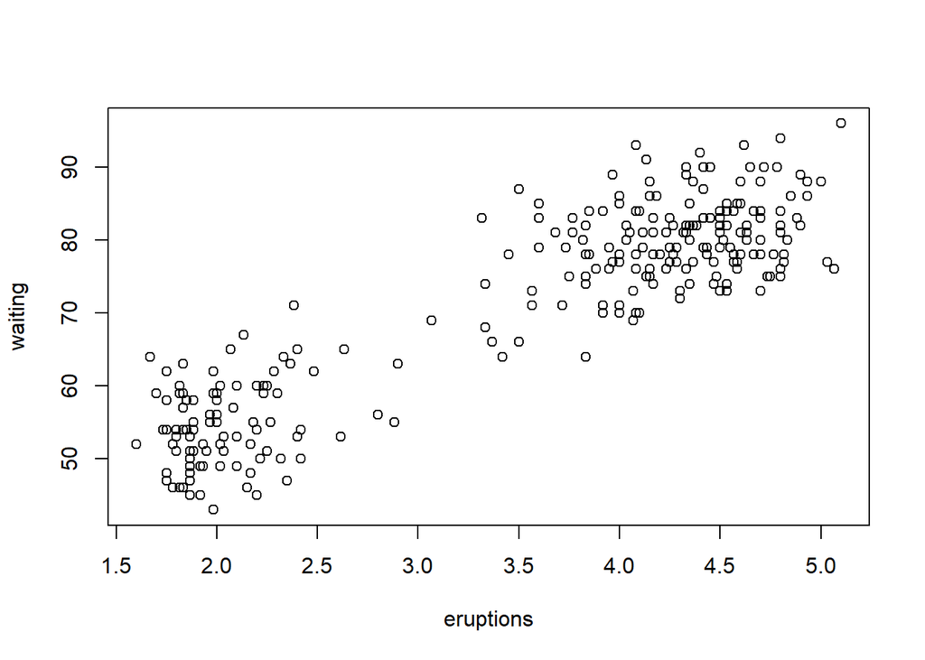

```r
plot(faithful)
```

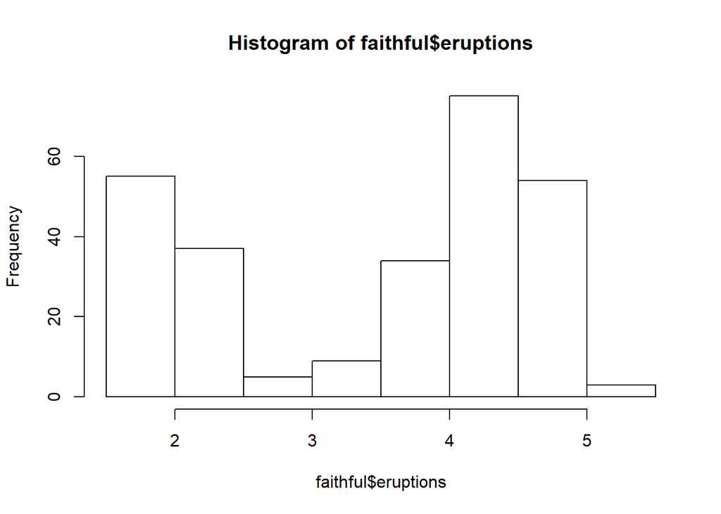

```r
hist(faithful$eruptions)
```

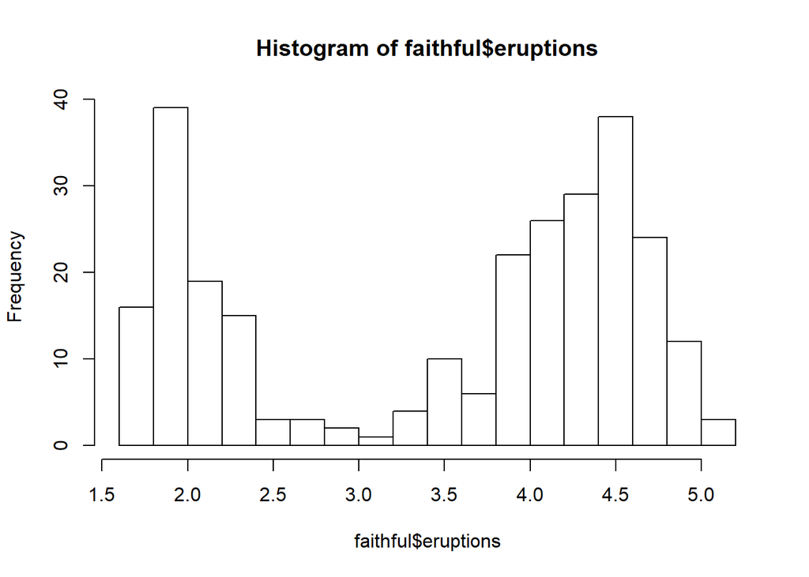

```r
hist(faithful$eruptions,breaks=seq(1.6,5.2,0.2))
```

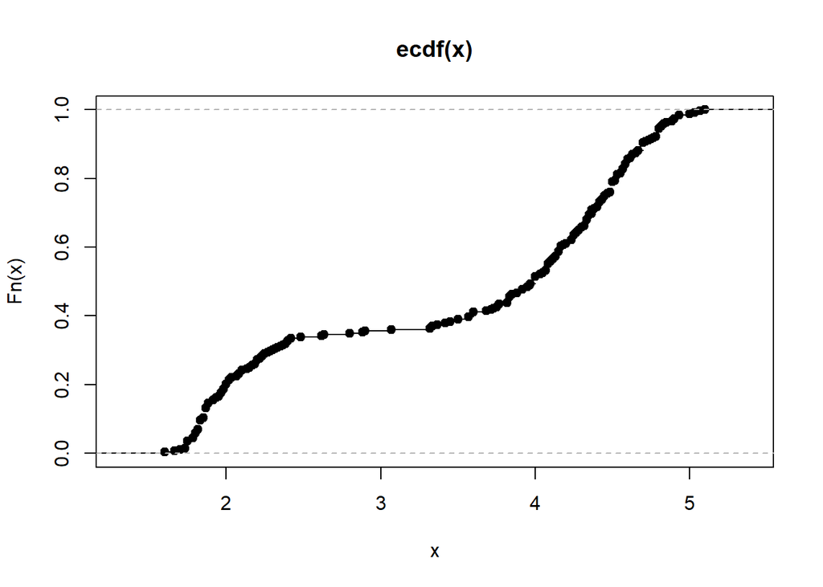

```r
plot.ecdf(faithful$eruptions)
```

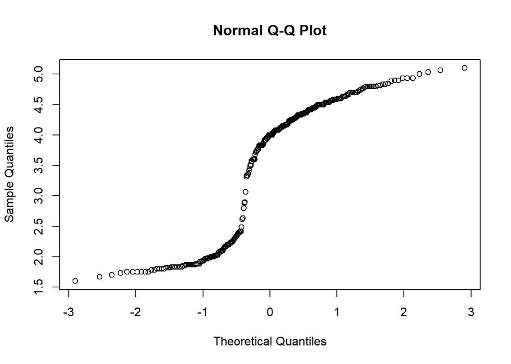

```r
qqnorm(faithful$eruptions)
```

We can see that the distribution seems bimodal, with a mixture of two normals. We can split the data into two parts and check the QQ plot again.

```r
# To make it easier for, we assign the variable f to the dataset
data("faithful")              # lazy load "faithful"
delayedAssign("f", faithful)  # lazy assign "x" with a reference to "faithful"
rm(faithful)                  # remove "faithful

# in the faithful dataset, eruptions is the first column, so we can access like so
f[,1]
```

```
##   [1] 3.600 1.800 3.333 2.283 4.533 2.883 4.700 3.600 1.950 4.350 1.833
##  [12] 3.917 4.200 1.750 4.700 2.167 1.750 4.800 1.600 4.250 1.800 1.750
##  [23] 3.450 3.067 4.533 3.600 1.967 4.083 3.850 4.433 4.300 4.467 3.367
##  [34] 4.033 3.833 2.017 1.867 4.833 1.833 4.783 4.350 1.883 4.567 1.750
##  [45] 4.533 3.317 3.833 2.100 4.633 2.000 4.800 4.716 1.833 4.833 1.733
##  [56] 4.883 3.717 1.667 4.567 4.317 2.233 4.500 1.750 4.800 1.817 4.400
##  [67] 4.167 4.700 2.067 4.700 4.033 1.967 4.500 4.000 1.983 5.067 2.017
##  [78] 4.567 3.883 3.600 4.133 4.333 4.100 2.633 4.067 4.933 3.950 4.517
##  [89] 2.167 4.000 2.200 4.333 1.867 4.817 1.833 4.300 4.667 3.750 1.867
## [100] 4.900 2.483 4.367 2.100 4.500 4.050 1.867 4.700 1.783 4.850 3.683
## [111] 4.733 2.300 4.900 4.417 1.700 4.633 2.317 4.600 1.817 4.417 2.617
## [122] 4.067 4.250 1.967 4.600 3.767 1.917 4.500 2.267 4.650 1.867 4.167
## [133] 2.800 4.333 1.833 4.383 1.883 4.933 2.033 3.733 4.233 2.233 4.533
## [144] 4.817 4.333 1.983 4.633 2.017 5.100 1.800 5.033 4.000 2.400 4.600
## [155] 3.567 4.000 4.500 4.083 1.800 3.967 2.200 4.150 2.000 3.833 3.500
## [166] 4.583 2.367 5.000 1.933 4.617 1.917 2.083 4.583 3.333 4.167 4.333
## [177] 4.500 2.417 4.000 4.167 1.883 4.583 4.250 3.767 2.033 4.433 4.083
## [188] 1.833 4.417 2.183 4.800 1.833 4.800 4.100 3.966 4.233 3.500 4.366
## [199] 2.250 4.667 2.100 4.350 4.133 1.867 4.600 1.783 4.367 3.850 1.933
## [210] 4.500 2.383 4.700 1.867 3.833 3.417 4.233 2.400 4.800 2.000 4.150
## [221] 1.867 4.267 1.750 4.483 4.000 4.117 4.083 4.267 3.917 4.550 4.083
## [232] 2.417 4.183 2.217 4.450 1.883 1.850 4.283 3.950 2.333 4.150 2.350
## [243] 4.933 2.900 4.583 3.833 2.083 4.367 2.133 4.350 2.200 4.450 3.567
## [254] 4.500 4.150 3.817 3.917 4.450 2.000 4.283 4.767 4.533 1.850 4.250
## [265] 1.983 2.250 4.750 4.117 2.150 4.417 1.817 4.467
```

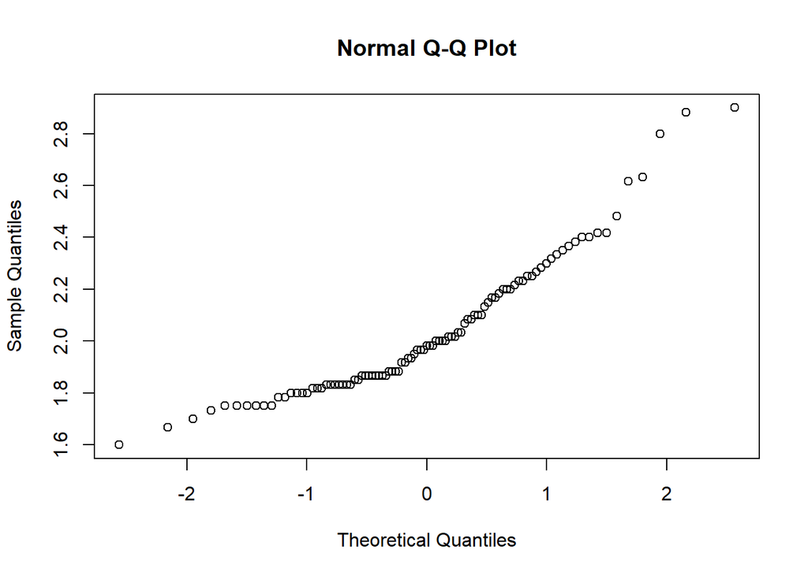

```r
# look at the qqplot for those values below 3
qqnorm(f[,1][f[,1]<=3])
```

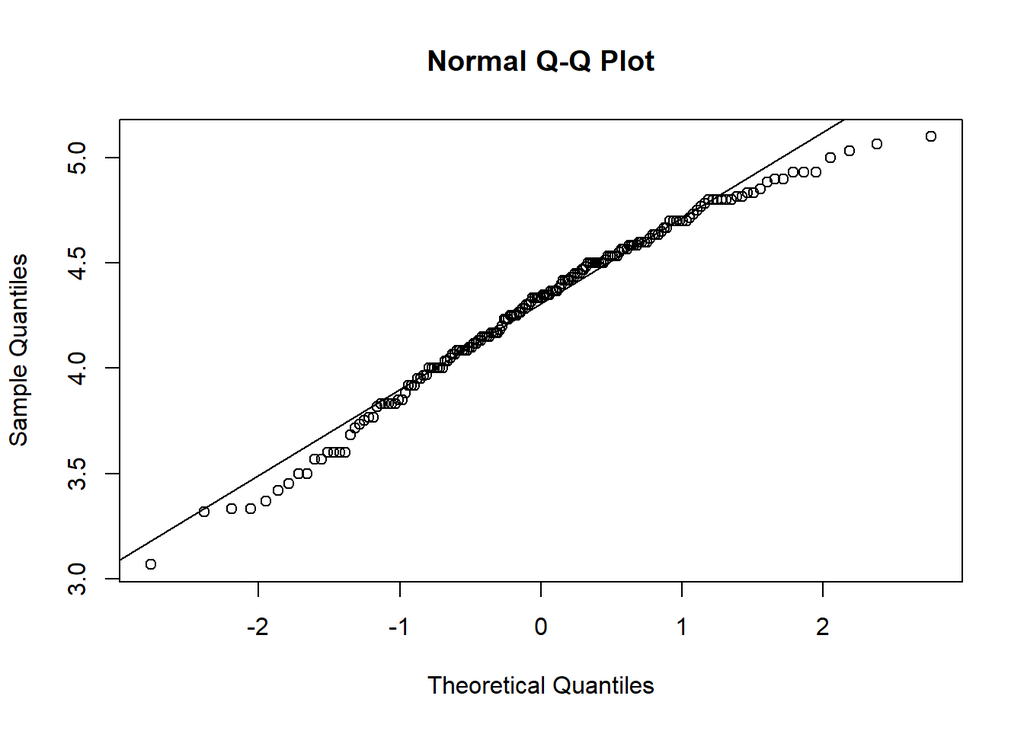

```r
# above 3
qqnorm(f[,1][f[,1]>3])
# draw qq line to see fit
qqline(f[,1][f[,1]>3])
```

With the other column, which is the waiting times, we can do a test:

```r
# subset to greater than 3
f_gr <- subset(f,f[,1]>3)
mean(f_gr[,2])
```

```
## [1] 79.98857
```

```r
t.test(f_gr[,2])
```

```
##
##  One Sample t-test
##
## data:  f_gr[, 2]
## t = 176.53, df = 174, p-value < 2.2e-16
## alternative hypothesis: true mean is not equal to 0
## 95 percent confidence interval:
##  79.09425 80.88289
## sample estimates:
## mean of x
##  79.98857
```

```r
t.test(f_gr[,2]-mean(f_gr[,2]))
```

```
##
##  One Sample t-test
##
## data:  f_gr[, 2] - mean(f_gr[, 2])
## t = -9.4987e-15, df = 174, p-value = 1
## alternative hypothesis: true mean is not equal to 0
## 95 percent confidence interval:
##  -0.8943228  0.8943228
## sample estimates:
##     mean of x
## -4.304047e-15
```

## More Data Visualisation

We will load the library `ggplot2`, and load the `WHO.csv`

```r
library(ggplot2)
setwd("D:/Downloads/40.220 The Analytics Edge/Week 1")
w <- read.csv("WHO.csv")
```

First, we look at the structure of the dataset:

```r
str(w)
```

```
## 'data.frame':    194 obs. of  9 variables:
##  $ Country       : Factor w/ 194 levels "Afghanistan",..: 1 2 3 4 5 6 7 8 9 10 ...
##  $ Region        : Factor w/ 6 levels "Africa","Americas",..: 3 4 1 4 1 2 2 4 6 4 ...
##  $ Population    : int  29825 3162 38482 78 20821 89 41087 2969 23050 8464 ...
##  $ Under15       : num  47.4 21.3 27.4 15.2 47.6 ...
##  $ Over60        : num  3.82 14.93 7.17 22.86 3.84 ...
##  $ FertilityRate : num  5.4 1.75 2.83 NA 6.1 2.12 2.2 1.74 1.89 1.44 ...
##  $ LifeExpectancy: int  60 74 73 82 51 75 76 71 82 81 ...
##  $ LiteracyRate  : num  NA NA NA NA 70.1 99 97.8 99.6 NA NA ...
##  $ GNI           : num  1140 8820 8310 NA 5230 ...
```

Taking a deeper look at Singapore, we look at the row:

```r
w[which(w$Country=="Singapore"),]
```

```
##       Country          Region Population Under15 Over60 FertilityRate
## 155 Singapore Western Pacific       5303   16.48  15.13          1.27
##     LifeExpectancy LiteracyRate   GNI
## 155             82         95.9 59380
```

To compare against the globe, we look at some summaries:

```r
summary(w$Under15)
```

```
##    Min. 1st Qu.  Median    Mean 3rd Qu.    Max.
##   13.12   18.72   28.65   28.73   37.75   49.99
```

```r
summary(w$Over60)
```

```
##    Min. 1st Qu.  Median    Mean 3rd Qu.    Max.
##    0.81    5.20    8.53   11.16   16.69   31.92
```

We can also look at some plots:

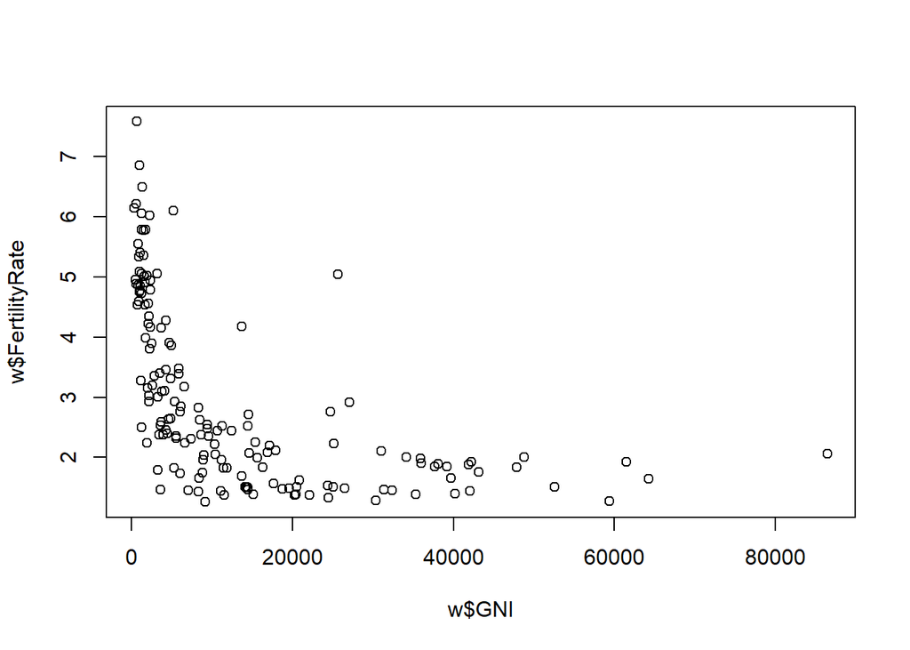

```r
plot(w$GNI,w$FertilityRate)
```

The plot suggests there is some negative correlation between GNI and Fertility rate.

Next, we will use the `ggplot2` library:

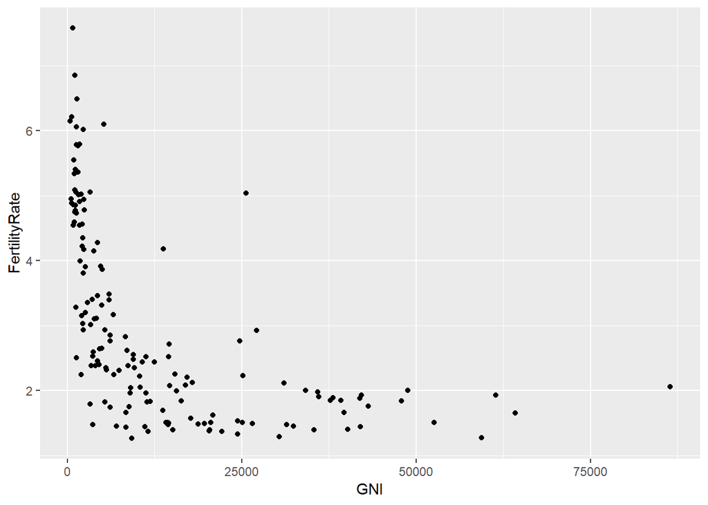

```r
# plot points only
ggplot(w,aes(x=GNI,y=FertilityRate)) + geom_point()
```

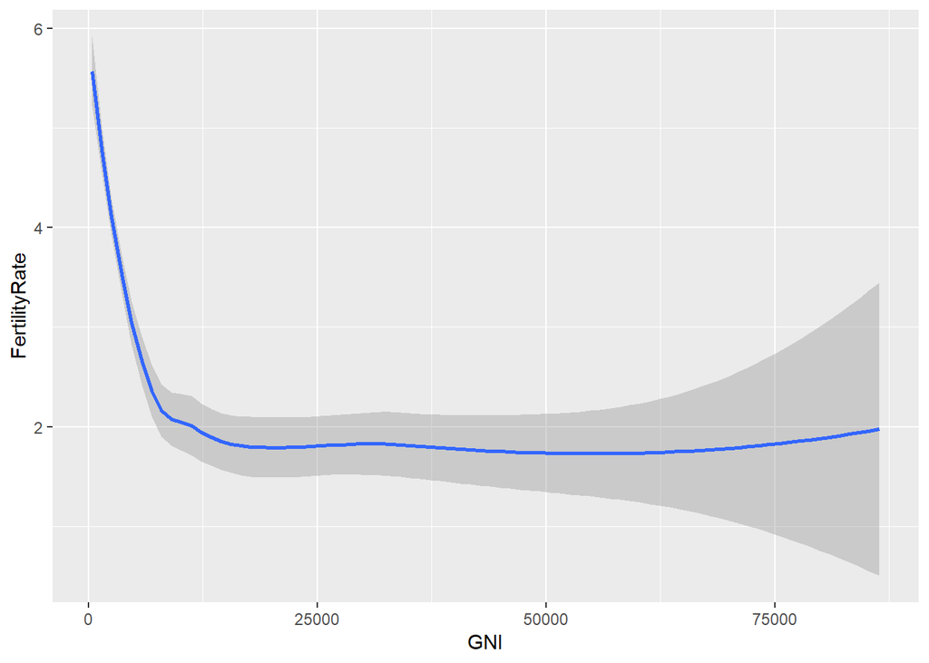

```r
# plot with some non-linear fit
ggplot(w,aes(x=GNI,y=FertilityRate)) + geom_smooth()
```

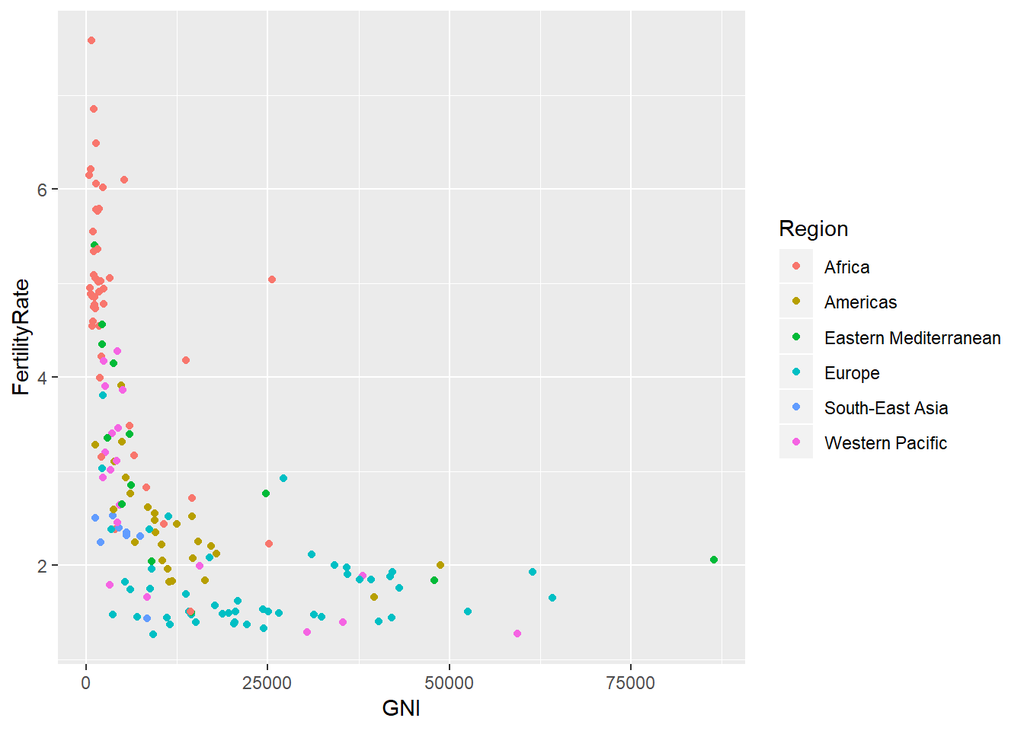

```r
# color by region
ggplot(w,aes(x=GNI,y=FertilityRate,color=Region)) + geom_point()
```

Next, we explore the crime dataset from Chicago.

```r
setwd("D:/Downloads/40.220 The Analytics Edge/Week 1")
x <- read.csv("crime.csv")
```

We can take a short look at the first few entries in our dataset

```r
head(x)
```

```
##             Date Latitude Longitude
## 1 12/31/12 23:15 41.75628 -87.62164
## 2 12/31/12 22:00 41.89879 -87.66130
## 3 12/31/12 22:00 41.96919 -87.76767
## 4 12/31/12 22:00 41.76933 -87.65773
## 5 12/31/12 21:30 41.83757 -87.62176
## 6 12/31/12 20:30 41.92856 -87.75400
```

We will need to format the time column in the dataset:

```r
x$Date <- strptime(x$Date,format="%m/%d/%y %H:%M")
```

With this, we can apply the `weekdays` command, which we add to a new column

```r
x$Weekday <- weekdays(x$Date)
table(x$Weekday)
```

```
##
##    Friday    Monday  Saturday    Sunday  Thursday   Tuesday Wednesday
##     28545     27372     27406     26723     27067     27141     27387
```

```r
library(maps)
library(ggmap)
```

We can get te map information of Chicago, which we will assign to a variable called `chicago`.

[figure not shown]

```r
chicago <- get_map(location="chicago")
ggmap(chicago)
```

We need to prepare the data

```r
LatLongCount <- as.data.frame(table(round(x[,3],2),round(x[,2],2)))
for (i in c(1,2)){
 LatLongCount[,i] <- as.numeric(as.character(LatLongCount[,i]))
}
```

[figure not shown]

```r
ggmap(chicago) + geom_tile(data=LatLongCount,aes(x=Var1,y=Var2,alpha=Freq),fill="red")
```

# Week 2

We load the dataset using `setwd` and `read.csv`.

```r
setwd("D:/Downloads/40.220 The Analytics Edge/Week 2")
wine <- read.csv("wine.csv")
```

We look at the structure of the data,

```r
str(wine)
```

```
## 'data.frame':    38 obs. of  6 variables:
##  $ VINT   : int  1952 1953 1954 1955 1956 1957 1958 1959 1960 1961 ...
##  $ LPRICE : num  -0.999 -0.454 NA -0.808 NA ...
##  $ WRAIN  : int  600 690 430 502 440 420 582 485 763 830 ...
##  $ DEGREES: num  17.1 16.7 15.4 17.1 15.6 ...
##  $ HRAIN  : int  160 80 180 130 140 110 187 187 290 38 ...
##  $ TIME_SV: int  31 30 29 28 27 26 25 24 23 22 ...
```

and then check for `NA` values.

```r
is.na(wine)
```

```
##        VINT LPRICE WRAIN DEGREES HRAIN TIME_SV
##  [1,] FALSE  FALSE FALSE   FALSE FALSE   FALSE
##  [2,] FALSE  FALSE FALSE   FALSE FALSE   FALSE
##  [3,] FALSE   TRUE FALSE   FALSE FALSE   FALSE
##  [4,] FALSE  FALSE FALSE   FALSE FALSE   FALSE
##  [5,] FALSE   TRUE FALSE   FALSE FALSE   FALSE
##  [6,] FALSE  FALSE FALSE   FALSE FALSE   FALSE
##  [7,] FALSE  FALSE FALSE   FALSE FALSE   FALSE
##  [8,] FALSE  FALSE FALSE   FALSE FALSE   FALSE
##  [9,] FALSE  FALSE FALSE   FALSE FALSE   FALSE
## [10,] FALSE  FALSE FALSE   FALSE FALSE   FALSE
## [11,] FALSE  FALSE FALSE   FALSE FALSE   FALSE
## [12,] FALSE  FALSE FALSE   FALSE FALSE   FALSE
## [13,] FALSE  FALSE FALSE   FALSE FALSE   FALSE
## [14,] FALSE  FALSE FALSE   FALSE FALSE   FALSE
```

[output cut: 24 more lines]

We start plotting

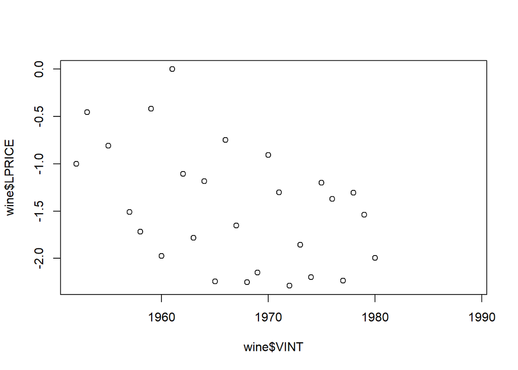

```r
plot(wine$VINT,wine$LPRICE)
```

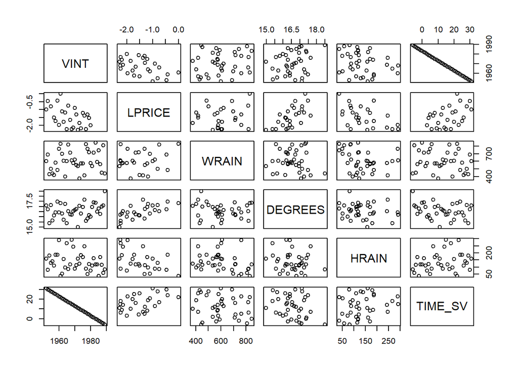

```r
pairs(wine)
```

We can take a deeper look int the data by subsetting it

```r
winetrain <- subset(wine,wine$VINT <= 1978 & !is.na(wine$LPRICE))
winetest <- subset(wine,wine$VINT > 1978)
```

We are going to use linear regression, which is the following model:
$$y_{i}=\beta_{0}+\sum_{j}\beta{j}x_{ij}+\epsilon_{i}\\
\min_{\beta_{j},\forall j} \sum_{i}\left(y_{i}-\beta-\beta_{j}x_{ij}\right)\\
\forall i \in N, \forall j \in M$$

Now let’s take the linear model

```r
model <- lm(LPRICE~VINT,winetrain)
summary(model)
```

```
##
## Call:
## lm(formula = LPRICE ~ VINT, data = winetrain)
##
## Residuals:
##      Min       1Q   Median       3Q      Max
## -0.84574 -0.46266 -0.09462  0.48752  1.24478
##
## Coefficients:
##             Estimate Std. Error t value Pr(>|t|)
## (Intercept) 72.99301   30.98789   2.356   0.0274 *
## VINT        -0.03786    0.01576  -2.402   0.0248 *
## ---
## Signif. codes:  0 '***' 0.001 '**' 0.01 '*' 0.05 '.' 0.1 ' ' 1
##
## Residual standard error: 0.594 on 23 degrees of freedom
## Multiple R-squared:  0.2005, Adjusted R-squared:  0.1657
## F-statistic: 5.768 on 1 and 23 DF,  p-value: 0.0248
```

Back to plotting with the model:

```r
plot(winetrain$VINT,winetrain$LPRICE)
abline(model)
model$residuals
```

```
##           1           2           4           6           7           8
## -0.09461844  0.48751867  0.20967287 -0.41591292 -0.58534581  0.75106129
##           9          10          11          12          13          14
## -0.76799160  1.24477550  0.17691260 -0.46049029  0.17399681 -0.84573608
##          15          16          17          18          19          20
##  0.68463102 -0.18196187 -0.74040477 -0.60020767  0.68004944  0.32303654
##          21          22          23          24          25          26
## -0.62758635 -0.15793925 -0.46266215  0.57309496  0.43999206 -0.38454083
##          27
##  0.58065627
```

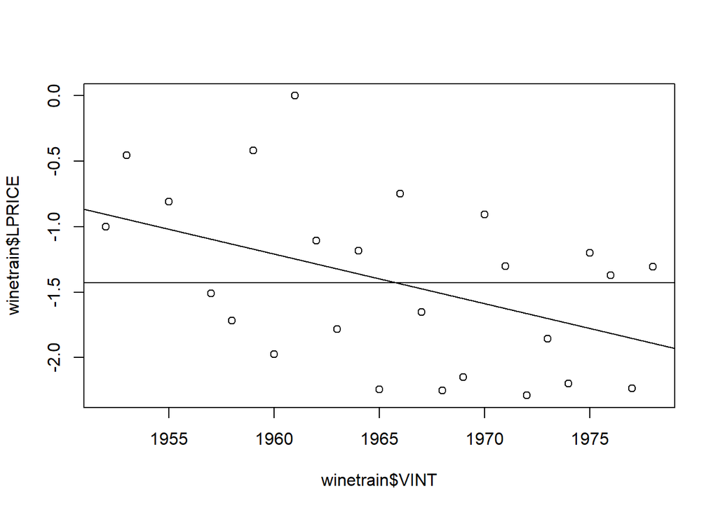

```r
sst <- sum((winetrain$LPRICE - mean(winetrain$LPRICE))^2)
sse <- sum(model$residuals^2)
rsq = 1- sse/sst
abline(a=mean(winetrain$LPRICE),b=0)
```

EXTRA We can do a generalised linear model

```r
library(glmulti)
```

```r
gmodel <- glmulti(LPRICE~., data = winetrain,
                  level = 2, method = "g",
                  plotty = FALSE,
                  report = FALSE)
```

[output not shown]

```r
summary(gmodel@objects[[1]])
```

```
##
## Call:
## fitfunc(formula = as.formula(x), data = data)
##
## Deviance Residuals:
##      Min        1Q    Median        3Q       Max
## -0.43372  -0.20499  -0.01433   0.20194   0.47979
##
## Coefficients:
##                 Estimate Std. Error t value Pr(>|t|)
## (Intercept)   -2.069e+00  2.845e-01  -7.271 4.94e-07 ***
## WRAIN:VINT    -7.666e-06  1.208e-06  -6.346 3.42e-06 ***
## WRAIN:DEGREES  1.033e-03  1.459e-04   7.079 7.31e-07 ***
## WRAIN:HRAIN   -9.909e-06  1.967e-06  -5.039 6.29e-05 ***
## HRAIN:TIME_SV  1.328e-04  5.501e-05   2.414   0.0255 *
## ---
## Signif. codes:  0 '***' 0.001 '**' 0.01 '*' 0.05 '.' 0.1 ' ' 1
##
## (Dispersion parameter for gaussian family taken to be 0.06971573)
##
##     Null deviance: 10.1506  on 24  degrees of freedom
## Residual deviance:  1.3943  on 20  degrees of freedom
## AIC: 10.785
##
## Number of Fisher Scoring iterations: 2
```

# Week 3

## Space Shuttle Challenger

We begin by reading the dataset.

```r
setwd("D:/Downloads/40.220 The Analytics Edge/Week 3")
orings <- read.csv("orings.csv")
str(orings)
```

```
## 'data.frame':    144 obs. of  5 variables:
##  $ Flight: Factor w/ 24 levels "1","2","3","41-B",..: 1 1 1 1 1 1 2 2 2 2 ...
##  $ Date  : Factor w/ 24 levels "1/12/1986","1/24/1985",..: 14 14 14 14 14 14 8 8 8 8 ...
##  $ Field : int  0 0 0 0 0 0 1 0 0 0 ...
##  $ Temp  : int  66 66 66 66 66 66 70 70 70 70 ...
##  $ Pres  : int  50 50 50 50 50 50 50 50 50 50 ...
```

```r
head(orings)
```

```
##   Flight      Date Field Temp Pres
## 1      1 4/12/1981     0   66   50
## 2      1 4/12/1981     0   66   50
## 3      1 4/12/1981     0   66   50
## 4      1 4/12/1981     0   66   50
## 5      1 4/12/1981     0   66   50
## 6      1 4/12/1981     0   66   50
```

```r
summary(orings)
```

```
##      Flight            Date         Field              Temp
##  1      :  6   1/12/1986 :  6   Min.   :0.00000   Min.   :31.00
##  2      :  6   1/24/1985 :  6   1st Qu.:0.00000   1st Qu.:66.75
##  3      :  6   1/28/1986 :  6   Median :0.00000   Median :70.00
##  41-B   :  6   10/3/1985 :  6   Mean   :0.07246   Mean   :67.96
##  41-C   :  6   10/30/1985:  6   3rd Qu.:0.00000   3rd Qu.:75.00
##  41-D   :  6   10/5/1984 :  6   Max.   :1.00000   Max.   :81.00
##  (Other):108   (Other)   :108   NA's   :6
##       Pres
##  Min.   : 50.0
##  1st Qu.: 87.5
##  Median :200.0
##  Mean   :154.2
##  3rd Qu.:200.0
##  Max.   :200.0
##
```

We can apply some functions to the dataset:

```r
tapply(orings[,3],orings[,1],sum) # col 3 is Field, col 1 is Flight
```

```
##    1    2    3 41-B 41-C 41-D 41-G    5 51-A 51-B 51-C 51-D 51-F 51-G 51-I
##    0    1    0    1    1    1    0    0    0    0    3    0    0    0    0
## 51-J    6 61-A 61-B 61-C 61-I    7    8    9
##    0    0    2    0    1   NA    0    0    0
```

```r
table(tapply(orings[,3],orings[,1],sum))
```

```
##
##  0  1  2  3
## 16  5  1  1
```

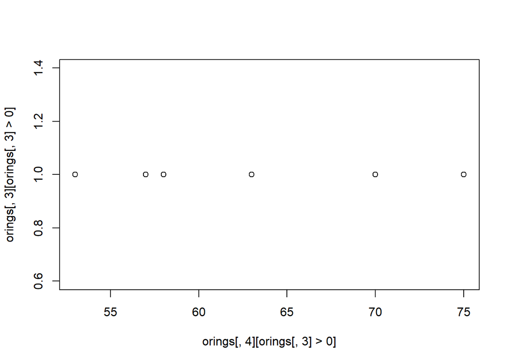

```r
plot(orings[,4][orings[,3]>0],orings[,3][orings[,3]>0]) #col 4 is temp
```

Adding some random noise,

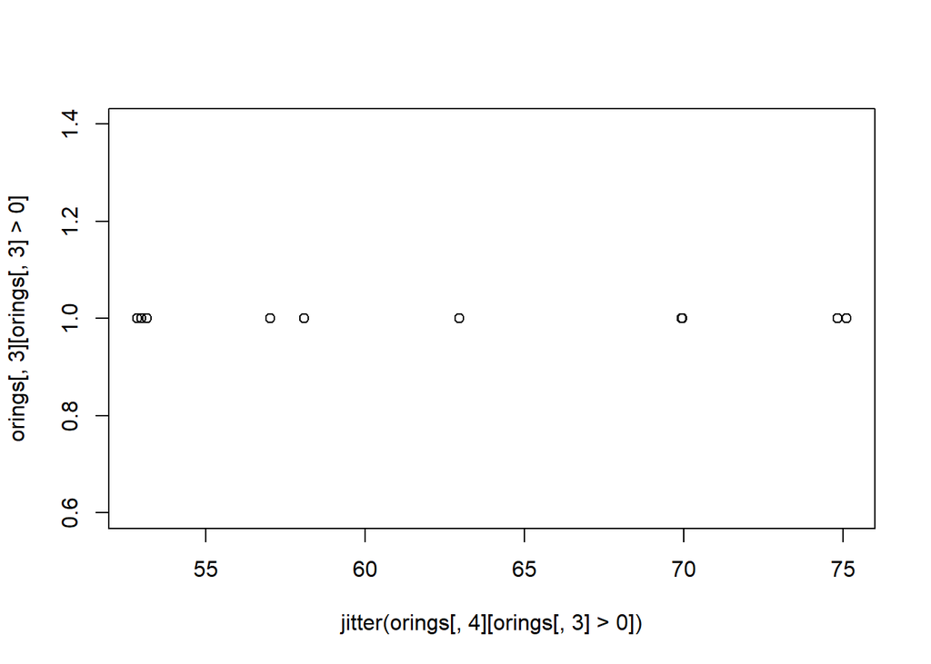

```r
plot(jitter(orings[,4][orings[,3]>0]),orings[,3][orings[,3]>0]) #col 4 is temp
```

Looking at the entire dataset:

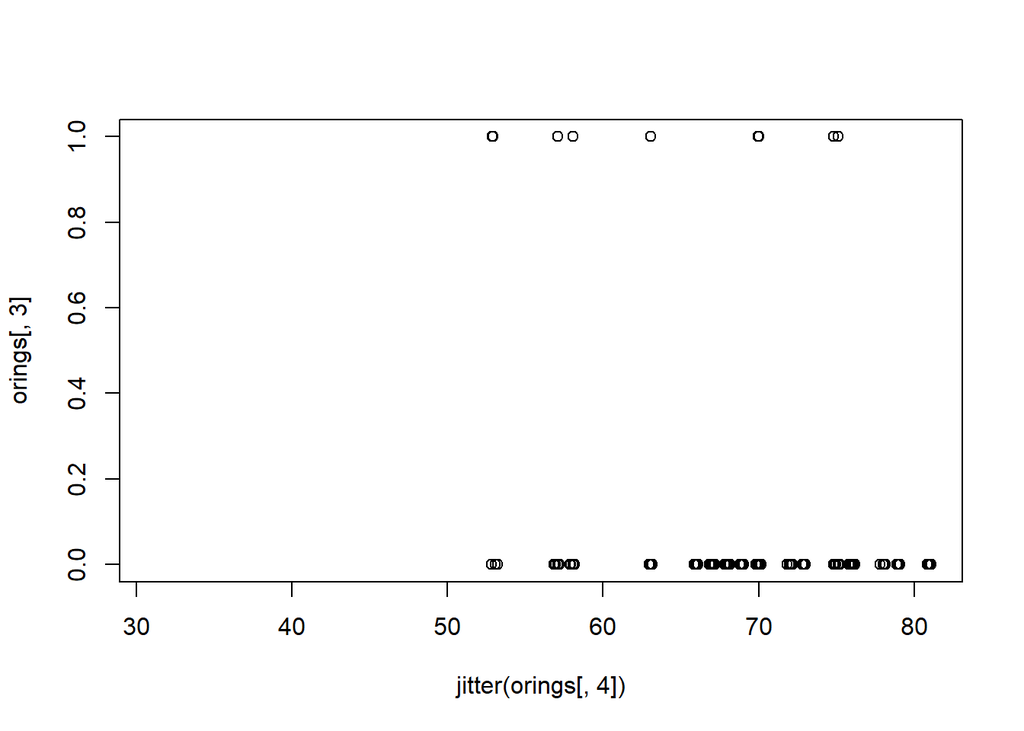

```r
plot(jitter(orings[,4]),orings[,3])
```

We can see that the majority of the high temperature points indicate less failures.

We use a linear regression first, which we will see is not appropriate.

```r
lin_mod <- lm(orings[,3]~orings[,4]) #failure vs temp
summary(lin_mod)
```

```
##
## Call:
## lm(formula = orings[, 3] ~ orings[, 4])
##
## Residuals:
##      Min       1Q   Median       3Q      Max
## -0.24546 -0.09925 -0.06792 -0.00526  0.98429
##
## Coefficients:
##              Estimate Std. Error t value Pr(>|t|)
## (Intercept)  0.798942   0.216289   3.694 0.000319 ***
## orings[, 4] -0.010443   0.003094  -3.375 0.000961 ***
## ---
## Signif. codes:  0 '***' 0.001 '**' 0.01 '*' 0.05 '.' 0.1 ' ' 1
##
## Residual standard error: 0.2509 on 136 degrees of freedom
##   (6 observations deleted due to missingness)
## Multiple R-squared:  0.0773, Adjusted R-squared:  0.07051
## F-statistic: 11.39 on 1 and 136 DF,  p-value: 0.0009612
```

```r
lin_mod2 <- lm(orings[,3]~orings[,4]+orings[,5]) #failure vs temp
summary(lin_mod2)
```

```
##
## Call:
## lm(formula = orings[, 3] ~ orings[, 4] + orings[, 5])
##
## Residuals:
##      Min       1Q   Median       3Q      Max
## -0.27680 -0.09548 -0.03457 -0.00874  0.99126
##
## Coefficients:
##               Estimate Std. Error t value Pr(>|t|)
## (Intercept)  0.7264305  0.2181384   3.330  0.00112 **
## orings[, 4] -0.0106657  0.0030704  -3.474  0.00069 ***
## orings[, 5]  0.0005783  0.0003176   1.821  0.07088 .
## ---
## Signif. codes:  0 '***' 0.001 '**' 0.01 '*' 0.05 '.' 0.1 ' ' 1
##
## Residual standard error: 0.2487 on 135 degrees of freedom
##   (6 observations deleted due to missingness)
## Multiple R-squared:  0.09941,    Adjusted R-squared:  0.08607
## F-statistic: 7.451 on 2 and 135 DF,  p-value: 0.0008524
```

```r
glmodel <- glm(orings[,3]~orings[,4]+orings[,5],family=binomial)
summary(glmodel)
```

```
##
## Call:
## glm(formula = orings[, 3] ~ orings[, 4] + orings[, 5], family = binomial)
##
## Deviance Residuals:
##     Min       1Q   Median       3Q      Max
## -0.9243  -0.3680  -0.2432  -0.2059   2.8217
##
## Coefficients:
##              Estimate Std. Error z value Pr(>|z|)
## (Intercept)  3.958071   3.497847   1.132  0.25781
## orings[, 4] -0.119355   0.044945  -2.656  0.00792 **
## orings[, 5]  0.008692   0.007689   1.130  0.25829
## ---
## Signif. codes:  0 '***' 0.001 '**' 0.01 '*' 0.05 '.' 0.1 ' ' 1
##
## (Dispersion parameter for binomial family taken to be 1)
##
##     Null deviance: 71.751  on 137  degrees of freedom
## Residual deviance: 60.470  on 135  degrees of freedom
##   (6 observations deleted due to missingness)
## AIC: 66.47
##
## Number of Fisher Scoring iterations: 6
```

The lower the AIC, the better. We can do a simple stepwise search:

```r
library(MASS)
stepAIC(glm(orings[,3]~.,family=binomial,data=orings))
```

```
## Start:  AIC=48
## orings[, 3] ~ Flight + Date + Field + Temp + Pres
```

```
##
## Step:  AIC=48
## orings[, 3] ~ Flight + Date + Field + Pres
```

```
##
## Step:  AIC=91
## orings[, 3] ~ Flight + Date + Pres
```

```
##
## Call:  glm(formula = orings[, 3] ~ Flight + Date + Pres, family = binomial,
##     data = orings)
##
## Coefficients:
##    (Intercept)         Flight2         Flight3      Flight41-B
##      1.721e+13      -1.721e+13      -1.721e+13      -1.721e+13
##     Flight41-C      Flight41-D      Flight41-G         Flight5
##     -1.721e+13      -1.721e+13      -1.721e+13      -1.721e+13
##     Flight51-A      Flight51-B      Flight51-C      Flight51-D
##     -1.721e+13      -1.721e+13      -1.721e+13      -1.721e+13
##     Flight51-F      Flight51-G      Flight51-I      Flight51-J
##     -1.721e+13      -1.721e+13      -1.721e+13      -1.721e+13
##        Flight6      Flight61-A      Flight61-B      Flight61-C
##     -1.721e+13      -1.721e+13      -1.721e+13      -1.721e+13
##        Flight7         Flight8         Flight9   Date1/24/1985
##     -1.721e+13      -1.721e+13      -1.721e+13              NA
##  Date10/3/1985  Date10/30/1985   Date10/5/1984  Date11/11/1982
##             NA              NA              NA              NA
## Date11/12/1981  Date11/26/1985  Date11/28/1983   Date11/8/1984
##             NA              NA              NA              NA
##   Date2/3/1984   Date3/22/1982   Date4/12/1981   Date4/12/1985
##             NA              NA      -4.521e+15              NA
##  Date4/29/1985    Date4/4/1983    Date4/6/1984   Date6/16/1983
##             NA              NA              NA              NA
##  Date6/17/1985   Date7/29/1985   Date8/27/1985   Date8/30/1983
##             NA              NA              NA              NA
##  Date8/30/1984            Pres
##             NA              NA
##
## Degrees of Freedom: 137 Total (i.e. Null);  114 Residual
##   (6 observations deleted due to missingness)
## Null Deviance:       71.75
## Residual Deviance: 43    AIC: 91
```

```r
library(glmulti)
oring_data_only <- orings[,-3]
glmulti_model_obj <- glmulti(orings[,3]~.,
                         data = oring_data_only,
                         level = 2,
                         plotty = F,
                         report = F,
                         method = "g")
```

```
## TASK: Genetic algorithm in the candidate set.
## Initialization...
## Algorithm started...
## Improvements in best and average IC have bebingo en below the specified goals.
## Algorithm is declared to have converged.
## Completed.
```

```r
print(glmulti_model_obj)
```

```
## glmulti.analysis
## Method: g / Fitting: glm / IC used: aic
## Level: 2 / Marginality: FALSE
## From 100 models:
## Best IC: 12.1085085000312
## Best model:
## [1] "orings[, 3] ~ 1 + Pres + Pres:Temp"
## Evidence weight: 0.298009475840397
## Worst IC: 28.2016271824286
## 5 models within 2 IC units.
## 4 models to reach 95% of evidence weight.
## Convergence after 140 generations.
## Time elapsed: 14.6620481014252 minutes.
```

```r
glmulti_model <- glmulti_model_obj@objects[[1]]
summary(glmulti_model)
```

```
##
## Call:
## fitfunc(formula = as.formula(x), data = data)
##
## Deviance Residuals:
##      Min        1Q    Median        3Q       Max
## -0.28257  -0.09479  -0.02802  -0.01647   0.98353
##
## Coefficients:
##               Estimate Std. Error t value Pr(>|t|)
## (Intercept) -9.632e-03  5.264e-02  -0.183 0.855090
## Pres         4.388e-03  1.132e-03   3.878 0.000164 ***
## Pres:Temp   -5.523e-05  1.557e-05  -3.547 0.000536 ***
## ---
## Signif. codes:  0 '***' 0.001 '**' 0.01 '*' 0.05 '.' 0.1 ' ' 1
##
## (Dispersion parameter for gaussian family taken to be 0.0616596)
##
##     Null deviance: 9.2754  on 137  degrees of freedom
## Residual deviance: 8.3240  on 135  degrees of freedom
##   (6 observations deleted due to missingness)
## AIC: 12.109
##
## Number of Fisher Scoring iterations: 2
```

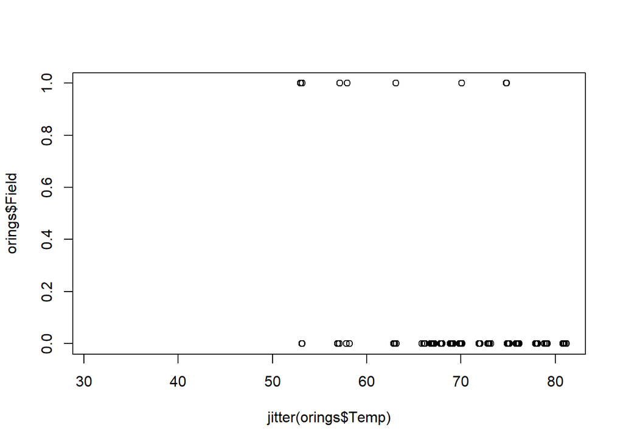

```r
plot(jitter(orings$Temp),orings$Field)
```

```r
# curve(exp(coef(glmodel)[1]+coef(glmodel)[2:3]*x)/(1+exp(coef(glmodel)[1]+coef(glmodel)[2:3]*x)),add=T)
```

```r
library(ROCR)
```

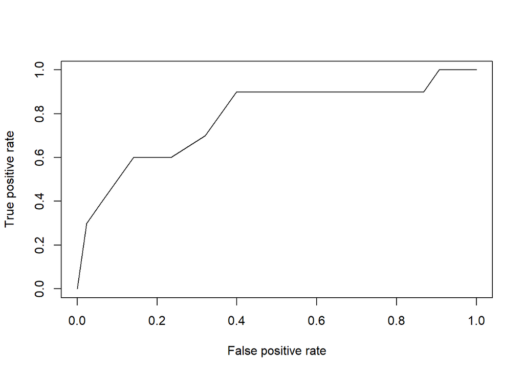

```r
pred <- predict(glmodel,newdata=orings,type="response")
# only up to 138 before incident
rocr_pred <- prediction(pred[1:138],orings[,3][1:138])
rocrperf <- performance(rocr_pred,measure="tpr",x.measure="fpr")
plot(rocrperf)
```

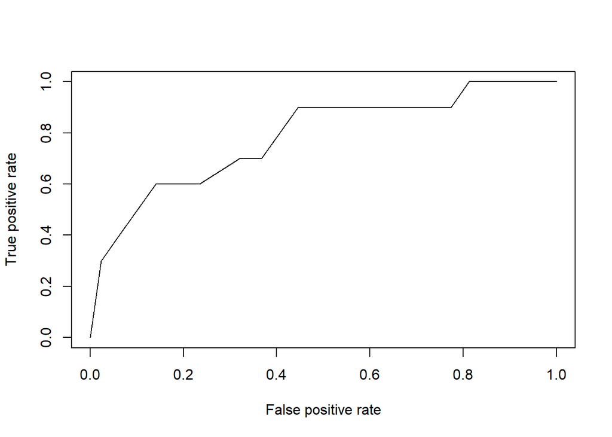

```r
pred <- predict(glmulti_model,newdata=orings,type="response")
# only up to 138 before incident
rocr_pred <- prediction(pred[1:138],orings[,3][1:138])
rocrperf <- performance(rocr_pred,measure="tpr",x.measure="fpr")
plot(rocrperf)
```

## Framingham Health Study

Next, we move on to the health dataset

```r
setwd("D:/Downloads/40.220 The Analytics Edge/Week 3")
fhs <- read.csv("framingham.csv")
str(fhs)
```

```
## 'data.frame':    11627 obs. of  39 variables:
##  $ RANDID  : int  2448 2448 6238 6238 6238 9428 9428 10552 10552 11252 ...
##  $ SEX     : int  1 1 2 2 2 1 1 2 2 2 ...
##  $ TOTCHOL : int  195 209 250 260 237 245 283 225 232 285 ...
##  $ AGE     : int  39 52 46 52 58 48 54 61 67 46 ...
##  $ SYSBP   : num  106 121 121 105 108 ...
##  $ DIABP   : num  70 66 81 69.5 66 80 89 95 109 84 ...
##  $ CURSMOKE: int  0 0 0 0 0 1 1 1 1 1 ...
##  $ CIGPDAY : int  0 0 0 0 0 20 30 30 20 23 ...
##  $ BMI     : num  27 NA 28.7 29.4 28.5 ...
##  $ DIABETES: int  0 0 0 0 0 0 0 0 0 0 ...
##  $ BPMEDS  : int  0 0 0 0 0 0 0 0 0 0 ...
##  $ HEARTRTE: int  80 69 95 80 80 75 75 65 60 85 ...
##  $ GLUCOSE : int  77 92 76 86 71 70 87 103 89 85 ...
##  $ educ    : int  4 4 2 2 2 1 1 3 3 3 ...
```

[output cut: 25 more lines]

```r
head(fhs)
```

```
##   RANDID SEX TOTCHOL AGE SYSBP DIABP CURSMOKE CIGPDAY   BMI DIABETES
## 1   2448   1     195  39 106.0  70.0        0       0 26.97        0
## 2   2448   1     209  52 121.0  66.0        0       0    NA        0
## 3   6238   2     250  46 121.0  81.0        0       0 28.73        0
## 4   6238   2     260  52 105.0  69.5        0       0 29.43        0
## 5   6238   2     237  58 108.0  66.0        0       0 28.50        0
## 6   9428   1     245  48 127.5  80.0        1      20 25.34        0
##   BPMEDS HEARTRTE GLUCOSE educ PREVCHD PREVAP PREVMI PREVSTRK PREVHYP TIME
## 1      0       80      77    4       0      0      0        0       0    0
## 2      0       69      92    4       0      0      0        0       0 4628
## 3      0       95      76    2       0      0      0        0       0    0
## 4      0       80      86    2       0      0      0        0       0 2156
## 5      0       80      71    2       0      0      0        0       0 4344
## 6      0       75      70    1       0      0      0        0       0    0
##   PERIOD HDLC LDLC DEATH ANGINA HOSPMI MI_FCHD ANYCHD STROKE CVD HYPERTEN
## 1      1   NA   NA     0      0      1       1      1      0   1        0
## 2      3   31  178     0      0      1       1      1      0   1        0
## 3      1   NA   NA     0      0      0       0      0      0   0        0
## 4      2   NA   NA     0      0      0       0      0      0   0        0
## 5      3   54  141     0      0      0       0      0      0   0        0
## 6      1   NA   NA     0      0      0       0      0      0   0        0
##   TIMEAP TIMEMI TIMEMIFC TIMECHD TIMESTRK TIMECVD TIMEDTH TIMEHYP
## 1   8766   6438     6438    6438     8766    6438    8766    8766
## 2   8766   6438     6438    6438     8766    6438    8766    8766
## 3   8766   8766     8766    8766     8766    8766    8766    8766
## 4   8766   8766     8766    8766     8766    8766    8766    8766
## 5   8766   8766     8766    8766     8766    8766    8766    8766
## 6   8766   8766     8766    8766     8766    8766    8766    8766
```

```r
summary(fhs)
```

```
##      RANDID             SEX           TOTCHOL           AGE
##  Min.   :   2448   Min.   :1.000   Min.   :107.0   Min.   :32.00
##  1st Qu.:2474378   1st Qu.:1.000   1st Qu.:210.0   1st Qu.:48.00
##  Median :5006008   Median :2.000   Median :238.0   Median :54.00
##  Mean   :5004741   Mean   :1.568   Mean   :241.2   Mean   :54.79
##  3rd Qu.:7472730   3rd Qu.:2.000   3rd Qu.:268.0   3rd Qu.:62.00
##  Max.   :9999312   Max.   :2.000   Max.   :696.0   Max.   :81.00
##                                    NA's   :409
##      SYSBP           DIABP           CURSMOKE         CIGPDAY
##  Min.   : 83.5   Min.   : 30.00   Min.   :0.0000   Min.   : 0.00
##  1st Qu.:120.0   1st Qu.: 75.00   1st Qu.:0.0000   1st Qu.: 0.00
##  Median :132.0   Median : 82.00   Median :0.0000   Median : 0.00
##  Mean   :136.3   Mean   : 83.04   Mean   :0.4325   Mean   : 8.25
##  3rd Qu.:149.0   3rd Qu.: 90.00   3rd Qu.:1.0000   3rd Qu.:20.00
##  Max.   :295.0   Max.   :150.00   Max.   :1.0000   Max.   :90.00
##                                                    NA's   :79
##       BMI           DIABETES           BPMEDS          HEARTRTE
##  Min.   :14.43   Min.   :0.00000   Min.   :0.0000   Min.   : 37.00
##  1st Qu.:23.09   1st Qu.:0.00000   1st Qu.:0.0000   1st Qu.: 69.00
##  Median :25.48   Median :0.00000   Median :0.0000   Median : 75.00
##  Mean   :25.88   Mean   :0.04558   Mean   :0.0856   Mean   : 76.78
##  3rd Qu.:28.07   3rd Qu.:0.00000   3rd Qu.:0.0000   3rd Qu.: 85.00
##  Max.   :56.80   Max.   :1.00000   Max.   :1.0000   Max.   :220.00
##  NA's   :52                        NA's   :593      NA's   :6
##     GLUCOSE            educ         PREVCHD            PREVAP
##  Min.   : 39.00   Min.   :1.00   Min.   :0.00000   Min.   :0.00000
##  1st Qu.: 72.00   1st Qu.:1.00   1st Qu.:0.00000   1st Qu.:0.00000
##  Median : 80.00   Median :2.00   Median :0.00000   Median :0.00000
##  Mean   : 84.12   Mean   :1.99   Mean   :0.07242   Mean   :0.05393
##  3rd Qu.: 89.00   3rd Qu.:3.00   3rd Qu.:0.00000   3rd Qu.:0.00000
##  Max.   :478.00   Max.   :4.00   Max.   :1.00000   Max.   :1.00000
##  NA's   :1440     NA's   :295
##      PREVMI           PREVSTRK          PREVHYP            TIME
##  Min.   :0.00000   Min.   :0.00000   Min.   :0.0000   Min.   :   0
##  1st Qu.:0.00000   1st Qu.:0.00000   1st Qu.:0.0000   1st Qu.:   0
##  Median :0.00000   Median :0.00000   Median :0.0000   Median :2156
##  Mean   :0.03217   Mean   :0.01307   Mean   :0.4596   Mean   :1957
##  3rd Qu.:0.00000   3rd Qu.:0.00000   3rd Qu.:1.0000   3rd Qu.:4252
##  Max.   :1.00000   Max.   :1.00000   Max.   :1.0000   Max.   :4854
##
```

[output cut: 25 more lines]

```
##  Min.   :   0   Min.   :   0   Min.   :   0   Min.   :   0
##  1st Qu.:7212   1st Qu.:7050   1st Qu.:5598   1st Qu.:7295
##  Median :8766   Median :8766   Median :8766   Median :8766
##  Mean   :7594   Mean   :7543   Mean   :7008   Mean   :7661
##  3rd Qu.:8766   3rd Qu.:8766   3rd Qu.:8766   3rd Qu.:8766
##  Max.   :8766   Max.   :8766   Max.   :8766   Max.   :8766
##
##     TIMECVD        TIMEDTH        TIMEHYP
##  Min.   :   0   Min.   :  26   Min.   :   0
##  1st Qu.:6004   1st Qu.:7798   1st Qu.:   0
##  Median :8766   Median :8766   Median :2429
##  Mean   :7166   Mean   :7854   Mean   :3599
##  3rd Qu.:8766   3rd Qu.:8766   3rd Qu.:7329
##  Max.   :8766   Max.   :8766   Max.   :8766
##
```

We wish to subset the data, looking only at people without a previous heart disease

```r
fhs_sub <- subset(fhs,PREVCHD==0 & PERIOD==1)
str(fhs_sub)
```

```
## 'data.frame':    4240 obs. of  39 variables:
##  $ RANDID  : int  2448 6238 9428 10552 11252 11263 12629 12806 14367 16365 ...
##  $ SEX     : int  1 2 1 2 2 2 2 2 1 1 ...
##  $ TOTCHOL : int  195 250 245 225 285 228 205 313 260 225 ...
##  $ AGE     : int  39 46 48 61 46 43 63 45 52 43 ...
##  $ SYSBP   : num  106 121 128 150 130 ...
##  $ DIABP   : num  70 81 80 95 84 110 71 71 89 107 ...
##  $ CURSMOKE: int  0 0 1 1 1 0 0 1 0 1 ...
##  $ CIGPDAY : int  0 0 20 30 23 0 0 20 0 30 ...
##  $ BMI     : num  27 28.7 25.3 28.6 23.1 ...
##  $ DIABETES: int  0 0 0 0 0 0 0 0 0 0 ...
##  $ BPMEDS  : int  0 0 0 0 0 0 0 0 0 0 ...
##  $ HEARTRTE: int  80 95 75 65 85 77 60 79 76 93 ...
##  $ GLUCOSE : int  77 76 70 103 85 99 85 78 79 88 ...
##  $ educ    : int  4 2 1 3 3 2 1 2 1 1 ...
```

[output cut: 25 more lines]

```r
length(unique(fhs_sub$RANDID))
```

```
## [1] 4240
```

We focus on ten years, and only on cardiovascular diseases (rather than other causes of death).

```r
fhs_sub$TENCHD <- as.integer((fhs_sub$TIMECHD/365)<=10)
colnames(fhs_sub)
```

```
##  [1] "RANDID"   "SEX"      "TOTCHOL"  "AGE"      "SYSBP"    "DIABP"
##  [7] "CURSMOKE" "CIGPDAY"  "BMI"      "DIABETES" "BPMEDS"   "HEARTRTE"
## [13] "GLUCOSE"  "educ"     "PREVCHD"  "PREVAP"   "PREVMI"   "PREVSTRK"
## [19] "PREVHYP"  "TIME"     "PERIOD"   "HDLC"     "LDLC"     "DEATH"
## [25] "ANGINA"   "HOSPMI"   "MI_FCHD"  "ANYCHD"   "STROKE"   "CVD"
## [31] "HYPERTEN" "TIMEAP"   "TIMEMI"   "TIMEMIFC" "TIMECHD"  "TIMESTRK"
## [37] "TIMECVD"  "TIMEDTH"  "TIMEHYP"  "TENCHD"
```

```r
which(colnames(fhs_sub)=="LDLC")
```

```
## [1] 23
```

```r
fhs_sub<-fhs_sub[,c(1:21,40)]
```

Subsetting further, we can examine what we have

```r
str(fhs_sub)
```

```
## 'data.frame':    4240 obs. of  22 variables:
##  $ RANDID  : int  2448 6238 9428 10552 11252 11263 12629 12806 14367 16365 ...
##  $ SEX     : int  1 2 1 2 2 2 2 2 1 1 ...
##  $ TOTCHOL : int  195 250 245 225 285 228 205 313 260 225 ...
##  $ AGE     : int  39 46 48 61 46 43 63 45 52 43 ...
##  $ SYSBP   : num  106 121 128 150 130 ...
##  $ DIABP   : num  70 81 80 95 84 110 71 71 89 107 ...
##  $ CURSMOKE: int  0 0 1 1 1 0 0 1 0 1 ...
##  $ CIGPDAY : int  0 0 20 30 23 0 0 20 0 30 ...
##  $ BMI     : num  27 28.7 25.3 28.6 23.1 ...
##  $ DIABETES: int  0 0 0 0 0 0 0 0 0 0 ...
##  $ BPMEDS  : int  0 0 0 0 0 0 0 0 0 0 ...
##  $ HEARTRTE: int  80 95 75 65 85 77 60 79 76 93 ...
##  $ GLUCOSE : int  77 76 70 103 85 99 85 78 79 88 ...
##  $ educ    : int  4 2 1 3 3 2 1 2 1 1 ...
##  $ PREVCHD : int  0 0 0 0 0 0 0 0 0 0 ...
##  $ PREVAP  : int  0 0 0 0 0 0 0 0 0 0 ...
##  $ PREVMI  : int  0 0 0 0 0 0 0 0 0 0 ...
##  $ PREVSTRK: int  0 0 0 0 0 0 0 0 0 0 ...
##  $ PREVHYP : int  0 0 0 1 0 1 0 0 1 1 ...
##  $ TIME    : int  0 0 0 0 0 0 0 0 0 0 ...
##  $ PERIOD  : int  1 1 1 1 1 1 1 1 1 1 ...
##  $ TENCHD  : int  0 0 0 1 0 0 1 0 0 0 ...
```

```r
head(fhs_sub)
```

```
##    RANDID SEX TOTCHOL AGE SYSBP DIABP CURSMOKE CIGPDAY   BMI DIABETES
## 1    2448   1     195  39 106.0    70        0       0 26.97        0
## 3    6238   2     250  46 121.0    81        0       0 28.73        0
## 6    9428   1     245  48 127.5    80        1      20 25.34        0
## 8   10552   2     225  61 150.0    95        1      30 28.58        0
## 10  11252   2     285  46 130.0    84        1      23 23.10        0
## 13  11263   2     228  43 180.0   110        0       0 30.30        0
##    BPMEDS HEARTRTE GLUCOSE educ PREVCHD PREVAP PREVMI PREVSTRK PREVHYP
## 1       0       80      77    4       0      0      0        0       0
## 3       0       95      76    2       0      0      0        0       0
## 6       0       75      70    1       0      0      0        0       0
## 8       0       65     103    3       0      0      0        0       1
## 10      0       85      85    3       0      0      0        0       0
## 13      0       77      99    2       0      0      0        0       1
##    TIME PERIOD TENCHD
## 1     0      1      0
## 3     0      1      0
## 6     0      1      0
## 8     0      1      1
## 10    0      1      0
## 13    0      1      0
```

Using a package, we can split the dataset into training and testing data.

```r
library(caTools)
set.seed(1) # for standardization with class
split <-sample.split(fhs_sub$TENCHD, SplitRatio = 0.65)
head(split)
```

```
## [1]  TRUE  TRUE  TRUE FALSE FALSE  TRUE
```

```r
train <- subset(fhs_sub,split==TRUE)
str(train)
```

```
## 'data.frame':    2756 obs. of  22 variables:
##  $ RANDID  : int  2448 6238 9428 11263 12629 16799 19304 20375 23727 30928 ...
##  $ SEX     : int  1 2 1 2 2 2 2 1 2 2 ...
##  $ TOTCHOL : int  195 250 245 228 205 254 247 294 332 221 ...
##  $ AGE     : int  39 46 48 43 63 50 43 46 41 38 ...
##  $ SYSBP   : num  106 121 128 180 138 ...
##  $ DIABP   : num  70 81 80 110 71 76 88 94 88 90 ...
##  $ CURSMOKE: int  0 0 1 0 0 0 0 1 0 1 ...
##  $ CIGPDAY : int  0 0 20 0 0 0 0 15 0 20 ...
##  $ BMI     : num  27 28.7 25.3 30.3 33.1 ...
##  $ DIABETES: int  0 0 0 0 0 0 0 0 0 0 ...
##  $ BPMEDS  : int  0 0 0 0 0 0 0 0 1 0 ...
##  $ HEARTRTE: int  80 95 75 77 60 75 72 98 65 95 ...
##  $ GLUCOSE : int  77 76 70 99 85 76 61 64 84 70 ...
##  $ educ    : int  4 2 1 2 1 1 2 1 3 2 ...
##  $ PREVCHD : int  0 0 0 0 0 0 0 0 0 0 ...
##  $ PREVAP  : int  0 0 0 0 0 0 0 0 0 0 ...
##  $ PREVMI  : int  0 0 0 0 0 0 0 0 0 0 ...
##  $ PREVSTRK: int  0 0 0 0 0 0 0 0 0 0 ...
##  $ PREVHYP : int  0 0 0 1 0 0 0 1 1 1 ...
##  $ TIME    : int  0 0 0 0 0 0 0 0 0 0 ...
##  $ PERIOD  : int  1 1 1 1 1 1 1 1 1 1 ...
##  $ TENCHD  : int  0 0 0 0 1 0 0 0 0 1 ...
```

```r
test <- subset(fhs_sub,split==FALSE)
str(test)
```

```
## 'data.frame':    1484 obs. of  22 variables:
##  $ RANDID  : int  10552 11252 12806 14367 16365 24721 34689 40435 43522 45464 ...
##  $ SEX     : int  2 2 2 1 1 2 2 2 2 2 ...
##  $ TOTCHOL : int  225 285 313 260 225 226 195 190 185 215 ...
##  $ AGE     : int  61 46 45 52 43 39 38 42 43 52 ...
##  $ SYSBP   : num  150 130 100 142 162 ...
##  $ DIABP   : num  95 84 71 89 107 64 84.5 70.5 77.5 82 ...
##  $ CURSMOKE: int  1 1 1 0 1 1 1 1 0 1 ...
##  $ CIGPDAY : int  30 23 20 0 30 9 5 30 0 20 ...
##  $ BMI     : num  28.6 23.1 21.7 26.4 23.6 ...
##  $ DIABETES: int  0 0 0 0 0 0 0 0 0 0 ...
##  $ BPMEDS  : int  0 0 0 0 0 0 0 0 0 0 ...
##  $ HEARTRTE: int  65 85 79 76 93 85 75 72 70 71 ...
##  $ GLUCOSE : int  103 85 78 79 88 NA 78 85 NA 75 ...
##  $ educ    : int  3 3 2 1 1 2 2 2 1 3 ...
##  $ PREVCHD : int  0 0 0 0 0 0 0 0 0 0 ...
##  $ PREVAP  : int  0 0 0 0 0 0 0 0 0 0 ...
##  $ PREVMI  : int  0 0 0 0 0 0 0 0 0 0 ...
##  $ PREVSTRK: int  0 0 0 0 0 0 0 0 0 0 ...
##  $ PREVHYP : int  1 0 0 1 1 0 0 0 0 0 ...
##  $ TIME    : int  0 0 0 0 0 0 0 0 0 0 ...
##  $ PERIOD  : int  1 1 1 1 1 1 1 1 1 1 ...
##  $ TENCHD  : int  1 0 0 0 0 0 0 0 0 0 ...
```

We can check that the subsets are balanced

```r
table(train$TENCHD)[2]/(table(train$TENCHD)[1]+table(train$TENCHD)[2])
```

```
##         1
## 0.1520319
```

```r
table(test$TENCHD)[2]/(table(test$TENCHD)[1]+table(test$TENCHD)[2])
```

```
##         1
## 0.1516173
```

Building the model,

```r
ml=glm(TENCHD~.,data=train,family=binomial)
summary(ml)
```

```
##
## Call:
## glm(formula = TENCHD ~ ., family = binomial, data = train)
##
## Deviance Residuals:
##     Min       1Q   Median       3Q      Max
## -2.2162  -0.6057  -0.4474  -0.3029   2.7904
##
## Coefficients: (5 not defined because of singularities)
##               Estimate Std. Error z value Pr(>|z|)
## (Intercept) -6.874e+00  8.700e-01  -7.902 2.75e-15 ***
## RANDID      -3.594e-09  2.061e-08  -0.174 0.861547
## SEX         -5.471e-01  1.331e-01  -4.111 3.94e-05 ***
## TOTCHOL      1.887e-03  1.376e-03   1.371 0.170246
## AGE          5.475e-02  8.083e-03   6.773 1.26e-11 ***
## SYSBP        1.231e-02  4.684e-03   2.628 0.008601 **
## DIABP       -2.138e-03  7.979e-03  -0.268 0.788704
## CURSMOKE    -1.219e-01  1.943e-01  -0.628 0.530190
## CIGPDAY      2.168e-02  7.823e-03   2.771 0.005584 **
## BMI          1.234e-02  1.526e-02   0.809 0.418782
## DIABETES    -1.934e-01  3.897e-01  -0.496 0.619678
## BPMEDS       7.219e-02  3.027e-01   0.238 0.811495
## HEARTRTE    -1.251e-03  5.104e-03  -0.245 0.806357
## GLUCOSE      1.034e-02  3.056e-03   3.384 0.000715 ***
## educ        -4.412e-02  6.049e-02  -0.729 0.465841
## PREVCHD             NA         NA      NA       NA
## PREVAP              NA         NA      NA       NA
## PREVMI              NA         NA      NA       NA
## PREVSTRK    -2.027e-01  6.845e-01  -0.296 0.767168
## PREVHYP      2.609e-01  1.669e-01   1.563 0.117958
## TIME                NA         NA      NA       NA
## PERIOD              NA         NA      NA       NA
## ---
## Signif. codes:  0 '***' 0.001 '**' 0.01 '*' 0.05 '.' 0.1 ' ' 1
##
## (Dispersion parameter for binomial family taken to be 1)
##
##     Null deviance: 2037.5  on 2383  degrees of freedom
## Residual deviance: 1834.1  on 2367  degrees of freedom
##   (372 observations deleted due to missingness)
## AIC: 1868.1
##
## Number of Fisher Scoring iterations: 5
```

```r
ml3=glm(TENCHD~SEX+AGE+SYSBP+CIGPDAY+GLUCOSE,data=train,family=binomial)
summary(ml3)
```

```
##
## Call:
## glm(formula = TENCHD ~ SEX + AGE + SYSBP + CIGPDAY + GLUCOSE,
##     family = binomial, data = train)
##
## Deviance Residuals:
##     Min       1Q   Median       3Q      Max
## -2.3252  -0.5973  -0.4480  -0.3089   2.7699
##
## Coefficients:
##              Estimate Std. Error z value Pr(>|z|)
## (Intercept) -7.160110   0.524258 -13.658  < 2e-16 ***
## SEX         -0.540547   0.126240  -4.282 1.85e-05 ***
## AGE          0.059845   0.007537   7.940 2.02e-15 ***
## SYSBP        0.016072   0.002573   6.247 4.18e-10 ***
## CIGPDAY      0.018223   0.005058   3.602 0.000315 ***
## GLUCOSE      0.009935   0.002303   4.314 1.61e-05 ***
## ---
## Signif. codes:  0 '***' 0.001 '**' 0.01 '*' 0.05 '.' 0.1 ' ' 1
##
## (Dispersion parameter for binomial family taken to be 1)
##
##     Null deviance: 2143.5  on 2496  degrees of freedom
## Residual deviance: 1929.3  on 2491  degrees of freedom
##   (259 observations deleted due to missingness)
## AIC: 1941.3
##
## Number of Fisher Scoring iterations: 5
```

Trying an automated search:

```r
library(glmulti)
glmulti_model_obj <- glmulti(TENCHD~.,
                             data = train,
                             level = 1,
                             family = 'binomial',
                             plotty = F,
                             report = F,
                             method = "g",
                             popsize = 64,
                             conseq = 2)
```

```
## TASK: Genetic algorithm in the candidate set.
## Initialization...
## Algorithm started...
## Improvements in best and average IC have bebingo en below the specified goals.
## Algorithm is declared to have converged.
## Completed.
```

```r
print(glmulti_model_obj)
```

```
## glmulti.analysis
## Method: g / Fitting: glm / IC used: aic
## Level: 1 / Marginality: FALSE
## From 100 models:
## Best IC: 1858.24921917257
## Best model:
## [1] "TENCHD ~ 1 + SEX + TOTCHOL + AGE + SYSBP + CIGPDAY + BMI + BPMEDS + "
## [2] "    GLUCOSE + educ + PREVCHD + PREVHYP + TIME"
## [1] "TENCHD ~ 1 + SEX + TOTCHOL + AGE + SYSBP + CIGPDAY + BMI + BPMEDS + "
## [2] "    GLUCOSE + educ + PREVCHD + PREVMI + PREVHYP"
## [1] "TENCHD ~ 1 + SEX + TOTCHOL + AGE + SYSBP + CIGPDAY + BMI + BPMEDS + "
## [2] "    GLUCOSE + educ + PREVHYP"
## [1] "TENCHD ~ 1 + SEX + TOTCHOL + AGE + SYSBP + CIGPDAY + BMI + BPMEDS + "
## [2] "    GLUCOSE + educ + PREVCHD + PREVMI + PREVHYP + TIME"
## [1] "TENCHD ~ 1 + SEX + TOTCHOL + AGE + SYSBP + CIGPDAY + BMI + BPMEDS + "
```

[output cut: 19 more lines]

```r
glmulti_model <- glmulti_model_obj@objects[[1]]
summary(glmulti_model)
```

```
##
## Call:
## fitfunc(formula = as.formula(x), family = "binomial", data = data)
##
## Deviance Residuals:
##     Min       1Q   Median       3Q      Max
## -2.1676  -0.6021  -0.4461  -0.3049   2.7833
##
## Coefficients: (2 not defined because of singularities)
##              Estimate Std. Error z value Pr(>|z|)
## (Intercept) -7.043531   0.738360  -9.539  < 2e-16 ***
## SEX         -0.550485   0.131290  -4.193 2.75e-05 ***
## TOTCHOL      0.001852   0.001371   1.350 0.176892
## AGE          0.055580   0.007909   7.028 2.10e-12 ***
## SYSBP        0.011573   0.003547   3.263 0.001103 **
## CIGPDAY      0.018084   0.005213   3.469 0.000522 ***
## BMI          0.012246   0.014797   0.828 0.407870
## BPMEDS       0.059710   0.300512   0.199 0.842502
## GLUCOSE      0.009360   0.002349   3.984 6.76e-05 ***
## educ        -0.043324   0.060143  -0.720 0.471305
## PREVCHD            NA         NA      NA       NA
## PREVHYP      0.249785   0.164685   1.517 0.129331
## TIME               NA         NA      NA       NA
## ---
## Signif. codes:  0 '***' 0.001 '**' 0.01 '*' 0.05 '.' 0.1 ' ' 1
##
## (Dispersion parameter for binomial family taken to be 1)
##
##     Null deviance: 2041.3  on 2384  degrees of freedom
## Residual deviance: 1836.2  on 2374  degrees of freedom
##   (371 observations deleted due to missingness)
## AIC: 1858.2
##
## Number of Fisher Scoring iterations: 5
```

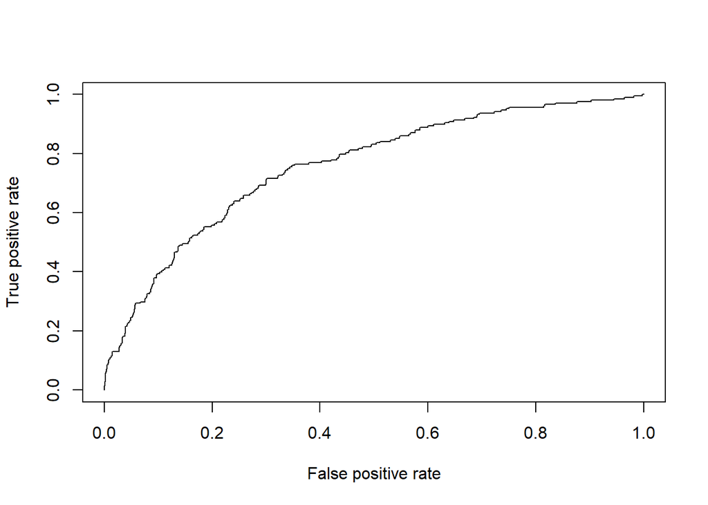

```r
library(ROCR)
pred <- predict(ml3, type="response", newdata = test)
rocr_pred <- prediction(pred,test$TENCHD)
rocrperf <- performance(rocr_pred,measure="tpr",x.measure="fpr")
plot(rocrperf)
```

```r
perf <- performance(rocr_pred, measure = "auc")
print(perf@y.values)
```

```
## [[1]]
## [1] 0.7574258
```

```r
pred <- predict(glmulti_model, type="response", newdata = test)
```

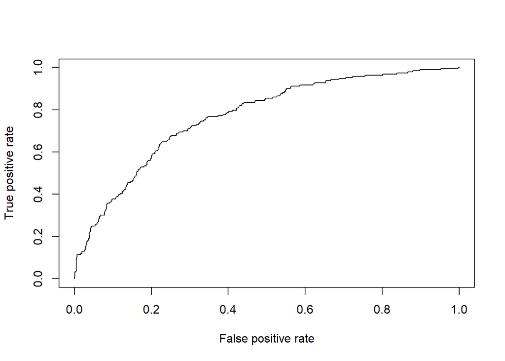

```r
rocr_pred <- prediction(pred,test$TENCHD)
rocrperf <- performance(rocr_pred,measure="tpr",x.measure="fpr")
plot(rocrperf)
```

```r
perf <- performance(rocr_pred, measure = "auc")
print(perf@y.values)
```

```
## [[1]]
## [1] 0.7689867
```

# Week 4